# Описание и проверка значимости линейных моделей

## Описание и проверка значимости линейных моделей

### Вы сможете

- Подобрать линейную модель зависимости переменной-отклика от одного предиктора
- Протестировать значимость линейной модели в целом и значимость отдельных ее коэффициентов при помощи t и F критериев

## Вспомним пример из прошлой лекции

## Пример: IQ и размеры мозга

Зависит ли уровень интеллекта от размера головного мозга? (Willerman et al. 1991)

[Scan_03_11](https://flic.kr/p/c45eZ3) by bucaorg(Paul_Burnett) on Flickr

Было исследовано 20 девушек и 20 молодых людей

У каждого индивида измеряли:

- вес
- рост
- размер головного мозга (количество пикселей на изображении ЯМР сканера)
- Уровень интеллекта измеряли с помощью IQ тестов

Пример: Willerman, L., Schultz, R., Rutledge, J. N., and Bigler, E. (1991), “In Vivo Brain Size and Intelligence”, Intelligence, 15, p.223–228.  
Данные: [“The Data and Story Library”](http://lib.stat.cmu.edu/DASL)  
Фото: [Scan_03_11](https://flic.kr/p/c45eZ3) by bucaorg (Paul Burnett) on Flickr

## Вспомним, на чем мы остановились

```
##
## Call:
## lm(formula = PIQ ~ MRINACount, data = brain)
##
## Residuals:
##    Min     1Q Median     3Q    Max
##  -39.6  -17.9   -1.6   17.0   42.3
##
## Coefficients:
##               Estimate Std. Error t value Pr(>|t|)
## (Intercept)  1.7437570 42.3923825    0.04    0.967
## MRINACount   0.0001203  0.0000465    2.59    0.014 *
## ---
## Signif. codes:  0 '***' 0.001 '**' 0.01 '*' 0.05 '.' 0.1 ' ' 1
##
## Residual standard error: 21 on 38 degrees of freedom
## Multiple R-squared:  0.15,   Adjusted R-squared:  0.127
## F-statistic: 6.69 on 1 and 38 DF,  p-value: 0.0137
```

## Уравнение и график зависимости

\[PIQ_i = 1.744 + 0.0001202 \cdot MRINACount_i\]

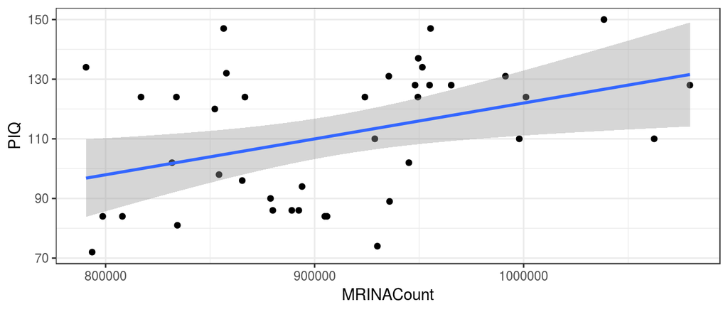

## Тестирование гипотез о линейных моделях

## Способы проверки значимости модели и ее коэффициентов

Два равноправных способа

### Значима ли модель целиком?

- F критерий

### Значима ли связь между предиктором и откликом?

- t-критерий
- F-критерий

## Тестирование гипотез с помощью t-критерия

## Тестирование гипотез с помощью t-критерия

### Гипотезы

Зависимость есть, если \(\beta_k \ne 0\)

Нулевая гипотеза \(H_0: \beta_k = 0\)

## Тестирование гипотез с помощью t-критерия

### Гипотезы

Зависимость есть, если \(\beta_k \ne 0\)

Нулевая гипотеза \(H_0: \beta_k = 0\)

### Тестовая статистика

\[t=\frac{b_k - \beta_k}{SE_{b_k}} = \frac{b_k - 0}{SE_{b_k}} = \frac{b_k}{SE_{b_k}}\]

Число степеней свободы: \(df = n − p\), где \(n\) — объем выборки, \(p\) — число параметров модели, \(k\) — конкретный коэффициент регрессии.

Для простой линейной регрессии с одним предиктором \(df = n - 2\).

## Зависит ли IQ от размера головного мозга?

\[PIQ_i = 1.744 + 0.0001202 \cdot MRINACount_i\]

```r
summary(brain_model)
```

```
##
## Call:
## lm(formula = PIQ ~ MRINACount, data = brain)
##
## Residuals:
##    Min     1Q Median     3Q    Max
##  -39.6  -17.9   -1.6   17.0   42.3
##
## Coefficients:
##               Estimate Std. Error t value Pr(>|t|)
## (Intercept)  1.7437570 42.3923825    0.04    0.967
## MRINACount   0.0001203  0.0000465    2.59    0.014 *
## ---
## Signif. codes:  0 '***' 0.001 '**' 0.01 '*' 0.05 '.' 0.1 ' ' 1
##
## Residual standard error: 21 on 38 degrees of freedom
## Multiple R-squared:  0.15,   Adjusted R-squared:  0.127
## F-statistic: 6.69 on 1 and 38 DF,  p-value: 0.0137
```

Результаты теста на IQ статистически значимо связаны  
с размерами мозга на МРТ (\(t_{0.05,\:38} = 2.59\), \(p = 0.01\)).

## Тестирование гипотез при помощи F-критерия

## Общая изменчивость

Общая изменчивость SS<sub>t</sub> — это сумма квадратов отклонений наблюдаемых значений \(y_i\) от общего среднего \(\bar y\)

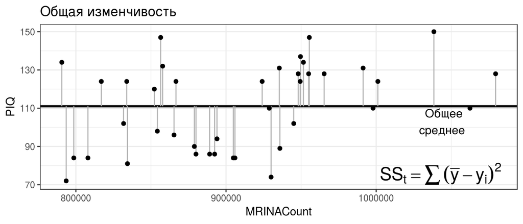

## Структура общей изменчивости

\[SS_t = SS_r + SS_e\]

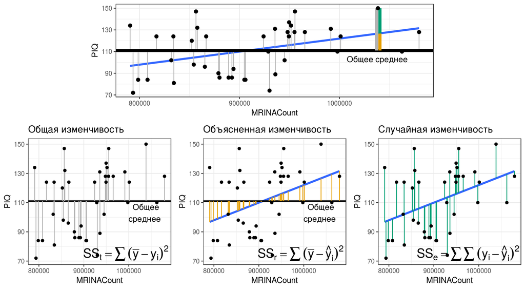

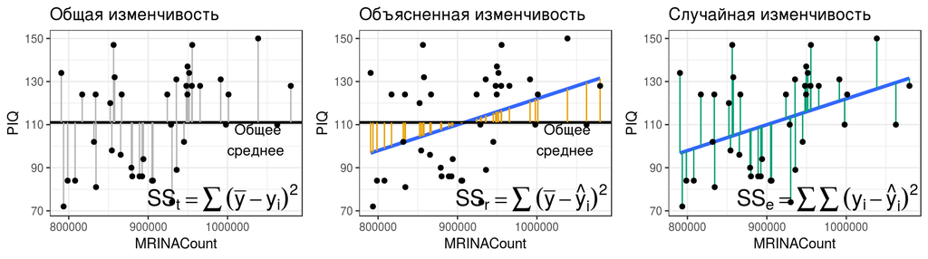

| \(MS_t\), полная дисперсия | \(MS_r\), дисперсия, объясненая регрессией | \(MS_e\), остаточная дисперсия |
| --- | --- | --- |
| \(MS_{t} =\frac{SS_{t}}{df_{t}}\) | \(MS_{r} =\frac{SS_{r}}{df_{r}}\) | \(MS_{e} =\frac{SS_{e}}{df_{e}}\) |
| \(SS_{t}=\sum{(\bar{y}-y_i)^2}\) | \(SS_{r}=\sum{(\hat{y}-\bar{y})^2}\) | \(SS_{e}=\sum{(\hat{y}-y_i)^2}\) |
| \(df_{t} = n-1\) | \(df_{r} = 1\) | \(df_{e} = n-2\) |

## С помощью \(MS_r\) и \(MS_e\) можно тестировать значимость коэффициентов

Если дисперсии остатков для всех значений x равны, то

\(E(MS_r) = \sigma^2 + \beta_1^2\sum(x_i - \bar x)^2\)

\(E(MS_e) =\sigma^2\)

## С помощью \(MS_r\) и \(MS_e\) можно тестировать значимость коэффициентов

Если дисперсии остатков для всех значений x равны, то

\(E(MS_r) = \sigma^2 + \beta_1^2\sum(x_i - \bar x)^2 = \sigma^2 + \sigma_{x}^2\)

\(E(MS_e) =\sigma^2\)

Если зависимости нет, то \(\beta_1 = 0\), и тогда Значит, \(MS_r \approx MS_e\)

## С помощью \(MS_r\) и \(MS_e\) можно тестировать значимость коэффициентов

Если дисперсии остатков для всех значений x равны, то

\(E(MS_r) = \sigma^2 + \beta_1^2\sum(x_i - \bar x)^2 = \sigma^2 + \sigma_{x}^2\)

\(E(MS_e) =\sigma^2\)

Если зависимости нет, то \(\beta_1 = 0\), и тогда Значит, \(MS_r \approx MS_e\)

- \(H_0: \beta_1 = 0\)
- \(H_A: \beta_1 \ne 0\)

\[ F_{df_r, df_e}= \frac{MS _{r}}{MS_{e}}\]

## Тестирование значимости коэффициентов регрессии при помощи F-критерия

- \(H_0: \beta_1 = 0\)
- \(H_A: \beta_1 \ne 0\)

\[ F_{df_r, df_e}= \frac{MS _{r}}{MS_{e}}\]

Для простой линейной регрессии \(df_{r} = 1\) и \(df_{e} = n - 2\)

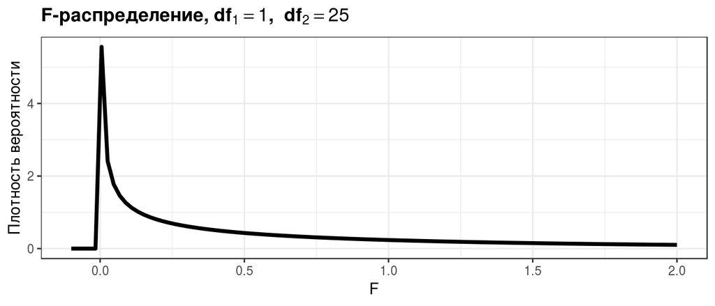

## Таблица результатов дисперсионного анализа

| Источник изменчивости | df | SS | MS | F |
| --- | --- | --- | --- | --- |
| Регрессия | \(df _r = 1\) | \(SS _r = \sum{(\bar y - \hat y _i)^2}\) | \(MS _r = \frac{SS _r}{df _r}\) | \(F _{df _r, df _e} = \frac{MS _r}{MS _e}\) |
| Остаточная | \(df _e = n - 2\) | \(SS _e = \sum{(y _i - \hat y _i)^2}\) | \(MS _e = \frac{SS _e}{df _e}\) |  |
| Общая | \(df _t = n - 1\) | \(SS _t = \sum {(\bar y - y _i)^2}\) |  |  |

Минимальное упоминание результатов в тексте должно содержать \(F _{df _r, df _e}\) и \(p\).

## Оценка качества подгонки модели

## В чем различие между этими двумя моделями?

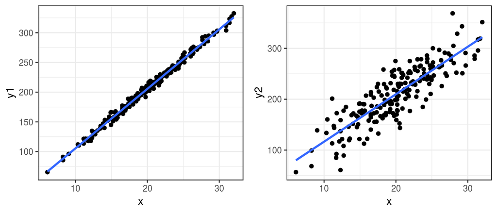

- У этих моделей разный разброс остатков:
- Модель слева объясняет практически всю изменчивость
- Модель справа объясняет не очень много изменчивости

## Коэффициент детерминации — мера качества подгонки модели

### Коэффициент детерминации

описывает какую долю дисперсии зависимой переменной объясняет модель

\[R^2 = \frac{SS_{r}}{SS_{t}}\]

- \(0 < R^2 < 1\)
- \(R^2 = r^2\) — для простой линейной регрессии коэффициент детерминации равен квадрату коэффициента Пирсоновской корреляции

## Если в модели много предикторов, нужно внести поправку

### Скорректированный коэффициет детерминации (adjusted R-squared)

Применяется если необходимо сравнить две модели с разным количеством параметров

\[ R^2_{adj} = 1- (1-R^2)\frac{n-1}{n-p}\]

\(p\) - количество параметров в модели

Вводится штраф за каждый новый параметр

## Еще раз смотрим на результаты регрессионного анализа зависимости IQ от размеров мозга

```r
summary(brain_model)
```

```
##
## Call:
## lm(formula = PIQ ~ MRINACount, data = brain)
##
## Residuals:
##    Min     1Q Median     3Q    Max
##  -39.6  -17.9   -1.6   17.0   42.3
##
## Coefficients:
##               Estimate Std. Error t value Pr(>|t|)
## (Intercept)  1.7437570 42.3923825    0.04    0.967
## MRINACount   0.0001203  0.0000465    2.59    0.014 *
## ---
## Signif. codes:  0 '***' 0.001 '**' 0.01 '*' 0.05 '.' 0.1 ' ' 1
##
## Residual standard error: 21 on 38 degrees of freedom
## Multiple R-squared:  0.15,   Adjusted R-squared:  0.127
## F-statistic: 6.69 on 1 and 38 DF,  p-value: 0.0137
```

## Как записываются результаты регрессионного анализа в тексте статьи?

- Неужели уже пора писать статью?

## Take-home messages

- Гипотезы о наличии зависимости можно тестировать при помощи t- или F-теста.
- Качество подгонки модели можно оценить при помощи коэффициента детерминации \(R^2\).
- У линейных моделей есть условия применимости, поэтому не спешите описывать результаты — сначала проверьте.

## Что почитать

- Гланц, С., 1998. Медико-биологическая статистика. М., Практика
- Кабаков Р.И. R в действии. Анализ и визуализация данных на языке R. М.: ДМК Пресс, 2014
- Diez, D.M., Barr, C.D. and Çetinkaya-Rundel, M., 2015. OpenIntro Statistics. OpenIntro.
- Zuur, A., Ieno, E.N. and Smith, G.M., 2007. Analyzing ecological data. Springer Science & Business Media.
- Quinn G.P., Keough M.J. 2002. Experimental design and data analysis for biologists
- Logan M. 2010. Biostatistical Design and Analysis Using R. A Practical Guide